# Chapter1_Review_Multiple Linear Regression

ML

10/20/2021

## Exercises

### Conceptual Exercises

1. **Applications that do not violate assumptions for inference in LLSR**. Identify the response and explanatory variable(s) for each problem. Write the LLSR assumptions for inference in the context of each study.
   1. **Cricket Chirps.** Researchers record the number of cricket chirps per minute and temperature during that time to investigate whether the number of chirps varies with the temperature.
   - *Response and variable: Number of cricket chirps per minute*
   - *Explanatory variable: Temperature*

   Assumptions:
   - *L: There is a linear relationship between temperature and the number of cricket chirps per minute*
   - *I: The number of cricket chirps per minute for each bird is independent. The selection of bird is independent.*
   - *N: The number of cricket chirps per minute at each temperature point vary and are normally distributed*
   - *E: The variation for the number of cricket chirps per minute should be approximately the same at each temperature point.*
   2. **Women’s Heights.** A random selection of women aged 20-24 years are selected and their shoe size is used to predict their height.
   - Response and variable: Height
   - Explanatory variable: Shoe size

   Assumptions:
   - L: Shoe size and height of women aged 20-24 years old are linearly related.
   - I: The height of women aged 20-24 years for shoe size is independent. Knowing one (X, Y) pair does not provide information about another.
   - N: The heights are normally distributed.
   - E: The standard deviation of heights is approximately the same for each shoe size.
1. **Applications that do violate assumptions for inference in LLSR**. All of the examples in this section have at least one violation of the LLSR assumptions for inference. Begin by identifying the response and explanatory variables. Then, identify which model assumption(s) are violated.
   1. **Low Birthweights.** Researchers are attempting to see if socioeconomic status and parental stability are predictive of low birthweight. They classify a child as having a low birthweight if their birthweight is less than 2,500 grams.
   - Response and variable: Low birthweight
   - Explanatory variable: Socioeconomic status and parental stability

   *Violated assumptions:*
   - **[Normality]** The low birthweight is not normally distributed.
   - The response is a binary outcome which violates the assumption of a normally distributed response at each level of X.
   - We will see logistic regression, which is more suitable for models with binary responses.
   - **[Errors]** The effect of SES and parental stability might be greater for babies with low birthweight than babies with normal birthweight.
   - The linearity assumption implies that there is a linear relationship in low birthweight and socioeconomic status and, similarly, a linear relationship in low birthweight and parental stability. This data may not be appropriate for LLSR modeling because the standard deviation in birthweight for family with low socioeconomic status at each level of parental stability might differ considerably from the standard deviation in birthweight for family with high socioeconomic status.
   - There may also be a problem with the independence assumption because there is no indication that the subjects were randomly selected. There may be subgroups of subjects likely to be more similar, e.g., selecting babies from one hospital and others from a different hospital.
   1. **Clinical Trial I.** A Phase II clinical trial is designed to compare the number of patients getting relief at different dose levels. 100 patients get dose A, 100 get dose B, and 100 get dose C.
   - Response and variable: Relief obtained
   - Explanatory variable: Dose levels (A, B, or C)

   *Violated assumptions:*
   - **[Normality]** The relief is measured in either Likert scale or Y/N response.
   - If the response is a binary outcome, it will violate the assumption of a normally distributed response at each level of X. Use Poisson models.
   1. **Canoes and Zip Codes.** For each of over 27,000 overnight permits for the Boundary Waters Canoe area, the zip code for the group leader has been translated to the distance traveled and socioeconomic data. Thus, for each zip code we can model the number of trips made as a function of distance traveled and various socioeconomic measures.

   Response and variable: The number of trips made Explanatory variable: Distance traveled and various socioeconomic measures

   *Violated assumptions:*
   - The number of trips is a count taking on integer values from 0 to (technically) no upper bound. The normality assumption may be problematic again because the distribution of number of trips is likely to be skewed, with most people travelled mostly 1-3 number of trips with fews travelled more than 3 trips to the same place.
   - The discrete nature of the response also indicates that we should consider the Poisson regression.
   - The data might not be independent. The zip code could correlate with the SES measures. People from certain zipcode areas could have similar SES.
   1. **Clinical Trial II.** A randomized clinical trial investigated postnatal depression and the use of an estrogen patch. Patients were randomly assigned to either use the patch or not. Depression scores were recorded on 6 different visits.
   - Response and variable: Depression scores on 6 different visits
   - Explanatory variable: The use the patch or not

   Violated assumptions:
   - The independence of observation will be violated because it is a repeated-measure (average score across of 6 visits).
2. **Kentucky Derby.** The next set of questions is related to the Kentucky Derby case study from this chapter.
   1. Discuss the pros and cons of using side-by-side boxplots vs. stacked histograms to illustrate the relationship between year and track condition in Figure @ref(fig:bivariate).
   - Pro: Side-by-side boxplots allows us to see the group differenes.
   - Pro: Stacked histogram allows us to see the normality
   2. Why is a scatterplot more informative than a correlation coefficient to describe the relationship between speed of the winning horse and year in Figure @ref(fig:bivariate).
   - Scatterplot allows us to evaluate whether there is a linear relationship between the variables and the spread of datapoints.
   - Correlation coefficient only allows us to know the strength and direction of the variables.
   3. How might you incorporate a fourth variable, say number of starters, into Figure @ref(fig:codeds)?
   - Use facet wrap
   4. Explain why $\epsilon_i$ in Equation @ref(eq:model1) measures the vertical distance from a data point to the regression line.
   - The vertical distance measures the deviations of the original data from the data from the expected data, modelled from the equation.
   - The part of a horse’s winning speed that is not explained by a linear trend over time.
   5. In the first t-test in Section @ref(SLRcontinuous) (t = 11.251 for $H_0:\beta_1 = 0$), notice that $t = \frac{\hat{\beta_1}}{SE(\beta_1)} = \frac{.026}{.0023} = 11.251$. Why is the t-test based on the ratio of the estimated slope to its standard error?
   6. In Equation @ref(eq:model3), explain why the t-test corresponding to $\beta_{1}$ is equivalent to an independent-samples t-test under equal variances. Why is the equal variance assumption needed?
   - For linear regression, we assume the variances of response variable for each group level is equal.
   - Because you are comparing two means, two different variances are obtained. If the variances are relatively equal, that is one sample variance is no larger than twice the size of the other, then you can assume equal variances.
   - Unequal variances (heteroscedasticity) can affect the Type I error rate and lead to false positives. If you are comparing two or more sample means, as in the 2-Sample t-test and ANOVA, a significantly different variance could overshadow the differences between means and lead to incorrect conclusions. [**homoscedasticity** residuals of your model need to roughly have a similar amount of deviations from your predicted values]
   7. When interpreting $\beta_2$ in Equation @ref(eq:model4), why do we have to be careful to say *for a fixed year* or *after adjusting for year*? Is it wrong to leave a qualifier like that off?
   - As the year is centered, we can rule out the effect of year on the speed of the horse. The increase in the estimate is purely based on the track in which the horse competes (fast and slow).
   8. Interpret in context a 95% confidence interval for $\beta_0$ in Model 4.
   - We can be 95% confident that the winning speed are between 50.61ft/s and 51.22ft/s in year 1896.
   1. State (in context) the result of a t-test for $\beta_1$ in Model 4.
   - The winning speeds increase by 0.023 ft/s per year, after accounting for track condition, t(119) = 11.77, p <.001.
   10. Why is there no $\epsilon_i$ term in Equation @ref(eq:model5est)?
   - It is a training data; it is the estimated prediction model for winning speeds, not actual winning speeds.
   11. If you considered the interaction between two continuous variables (like `yearnew` and `starters`), how would you provide an interpretation for that coefficient in context?
   - The amount of increase/decrease of the winning speed for the different starters at different years differ.
   12. Interpret (in context) the LLSR estimates for $\beta_3$ and $\beta_5$ in Equation @ref(eq:model0).
   - The winnings speed increase by 1.393 ft/s for fast track, after accounting for the year.
   - The winning speed decrease by 0.025 ft/s when the number of starter increases by 1 unit , after accounting for track condition and year.
3. **Moneyball.** In a 2011 article in *The Sport Journal*, Farrar and Bruggink [-@Farrar2011] attempt to show that Major League Baseball general managers did not immediately embrace the findings of Michael Lewis’s 2003 *Moneyball* book [@Lewis2003]. They contend that players’ on-base percentage remained relatively undercompensated compared to slugging percentage three years after the book came out. Two regression models are described: Team Run Production Model and Player Salary Model.
   1. Discuss potential concerns (if any) with the LINE assumptions for linear regression in each model.
   2. In Table 3, the authors contend that Model 1 is better than Model 3. Could you argue that Model 3 is actually better? How could you run a formal hypothesis test comparing Model 1 to Model 3?
   3. If authors had chosen Model 3 in Table 3 with the two interaction terms, how would that affect their final analysis, in which they compare coefficients of slugging and on-base percentage? (Hint: write out interpretations for the two interaction coefficients—the first one should be NL:OBP and the second one should be NL:SLG)
   4. The authors write that, “It should also be noted that the runs scored equation fit is better than the one Hakes and Sauer have for their winning equation.” What do you think they mean by this statement? Why might this comparison not be relevant?
   5. In Table 4, Model 1 has a higher adjusted $R^2$ than Model 2, yet the extra term in Model 1 (an indicator value for the National League) is not significant at the 5% level. Explain how this is possible.
   6. What limits does this paper have on providing guidance to baseball decision makers?

### Guided Exercises

1. **Gender discrimination in bank salaries**. In the 1970’s, Harris Trust was sued for gender discrimination in the salaries it paid its employees. One approach to addressing this issue was to examine the starting salaries of all skilled, entry-level clerical workers between 1965 and 1975. The following variables, which can be found in `banksalary.csv`, were collected for each worker [@Ramsey2002]:
   - `bsal` = beginning salary (annual salary at time of hire)
   - `sal77` = annual salary in 1977
   - `sex` = MALE or FEMALE
   - `senior` = months since hired
   - `age` = age in months
   - `educ` = years of education
   - `exper` = months of prior work experience

   Creating an indicator variable based on `sex` could be helpful.

```r
library(knitr)
library(gridExtra)
library(kableExtra)
library(jtools)
library(GGally)
library(rsample)
library(broom)
library(tidyverse)
banksalary <- read_csv("banksalary.csv")
```

1. Identify observational units, the response variable, and explanatory variables.
- Observational units: 93 observation units.
- Response variable: beginning salary (annual salary at time of hire)
- Explanatory variables: sex, sal77, senior, age, educ, exper
  2. The mean starting salary of male workers ($5957) was 16% higher than the mean starting salary of female workers ($5139). Confirm these mean salaries. Is this enough evidence to conclude gender discrimination exists? If not, what further evidence would you need?

```r
meanbsal <- banksalary %>% group_by(sex) %>% summarise(mean=mean(bsal))
```

- Not enough evidence. Evidence from statistical analysis needed.
  3. How would you expect age, experience, and education to be related to starting salary? Generate appropriate exploratory plots; are the relationships as you expected? What implications does this have for modeling?

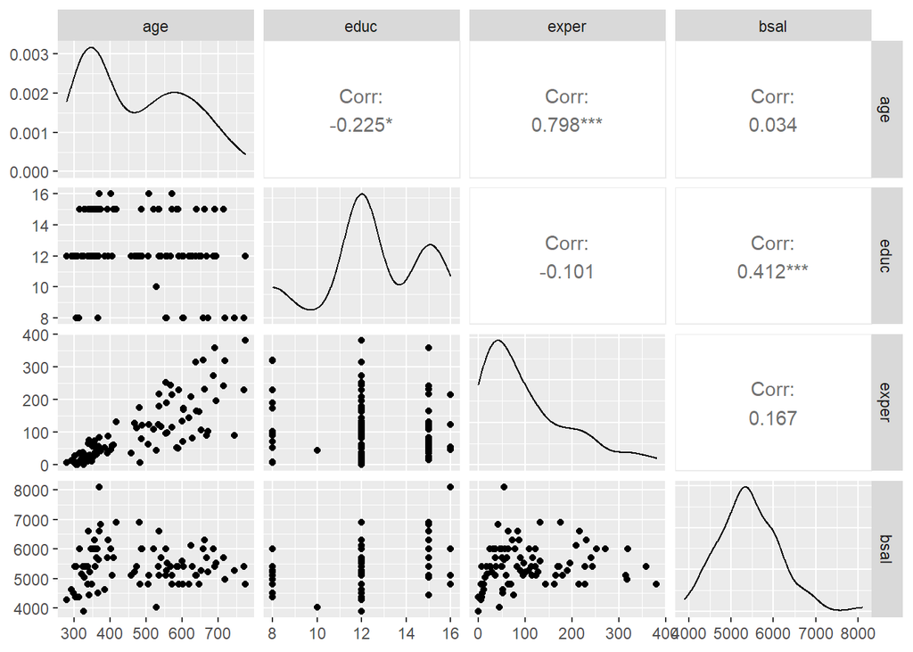

```r
ggpairs(data = banksalary,
columns = c("age", "educ", "exper", "bsal"))
```

- Age, experience and education are expected to correlate with starting salary. However, only education is correlated with starting salary, according to the plot. - Implication: Education should be taken into account when examining gender effect on starting salary.

```
d. Why might it be important to control for seniority (number of years with the bank) if we are only concerned with the salary when the worker started?
- The year of employment might affect the starting salary, and everyone has different starting point.

e. By referring to exploratory plots and summary statistics, are any explanatory variables (including sex) closely related to each other?  What implications does this have for modeling?
```

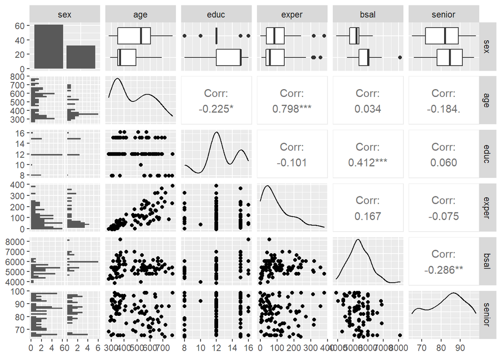

```r
ggpairs(data = banksalary,
columns = c("sex","age", "educ", "exper", "bsal", "senior"))
```

- Age and experience are closely related. We might consider including only one of the variables in the model.

```
f. Fit a simple linear regression model with starting salary as the response and experience as the sole explanatory variable (Model 1).  Interpret the intercept and slope of this model; also interpret the R-squared value.  Is there a significant relationship between experience and starting salary?
```

```r
model_bank <- lm(bsal ~ exper, data = banksalary)
summary(model_bank)
```

```
##
## Call:
## lm(formula = bsal ~ exper, data = banksalary)
##
## Residuals:
##      Min       1Q   Median       3Q      Max
## -1389.02  -503.33   -36.03   383.14  2740.08
##
## Coefficients:
##              Estimate Std. Error t value Pr(>|t|)
## (Intercept) 5289.0217   109.2984  48.391   <2e-16 ***
## exper          1.3009     0.8064   1.613     0.11
## ---
## Signif. codes:  0 '***' 0.001 '**' 0.01 '*' 0.05 '.' 0.1 ' ' 1
##
## Residual standard error: 703.5 on 91 degrees of freedom
## Multiple R-squared:  0.0278, Adjusted R-squared:  0.01712
## F-statistic: 2.602 on 1 and 91 DF,  p-value: 0.1102
```

```
-The model estimates that when experience is 0, the starting salary would be 5289.
-The model estimates that when starting salary increases by 1.30 with every unit increase in experience.
-Experience explained 1.71% of the variance in starting salary.
-No significant relationship between experience and starting salary.

g. Does Model 1 meet all linear least squares regression assumptions?  List each assumption and how you decided if it was met or not.
```

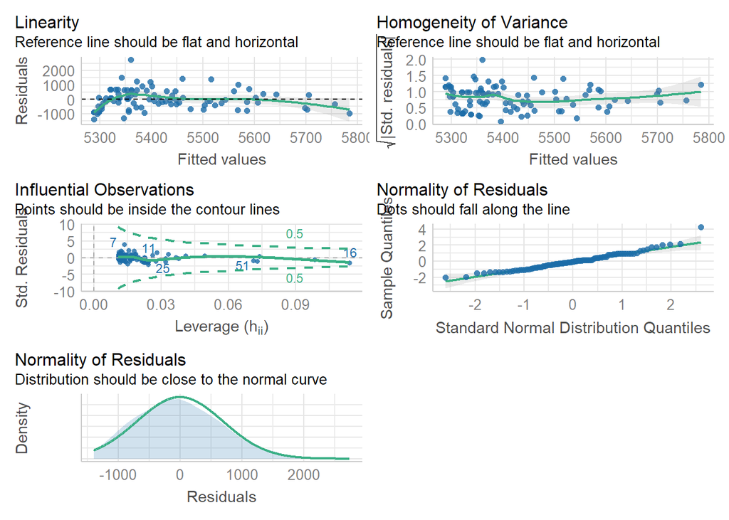

```r
library(performance)
check_model(model_bank)
```

- L: Linearity violated. - I: Not violated. - N: Not violated. - E: Violated.

```
h. Is a model with all 4 confounding variables (Model 2, with `senior`, `educ`, `exper`, and `age`) better than a model with just experience (Model 1)?  Justify with an appropriate significance test in addition to summary statistics of model performance.
```

```r
model_bank2 <- lm(bsal ~ senior + educ + exper + age, data = banksalary)
summary(model_bank2)
```

```
##
## Call:
## lm(formula = bsal ~ senior + educ + exper + age, data = banksalary)
##
## Residuals:
##      Min       1Q   Median       3Q      Max
## -1308.38  -378.67   -22.45   364.97  1873.29
##
## Coefficients:
##              Estimate Std. Error t value Pr(>|t|)
## (Intercept) 5879.5837   765.3756   7.682 2.06e-11 ***
## senior       -22.4400     6.2469  -3.592  0.00054 ***
## educ         130.1487    28.3551   4.590 1.47e-05 ***
## exper          2.7983     1.1586   2.415  0.01779 *
## age           -1.1022     0.7777  -1.417  0.15992
## ---
## Signif. codes:  0 '***' 0.001 '**' 0.01 '*' 0.05 '.' 0.1 ' ' 1
##
## Residual standard error: 599.4 on 88 degrees of freedom
## Multiple R-squared:  0.3176, Adjusted R-squared:  0.2866
## F-statistic: 10.24 on 4 and 88 DF,  p-value: 7.474e-07
```

```r
anova(model_bank, model_bank2)
```

```
## Analysis of Variance Table
##
## Model 1: bsal ~ exper
## Model 2: bsal ~ senior + educ + exper + age
##   Res.Df      RSS Df Sum of Sq      F    Pr(>F)
## 1     91 45035392
## 2     88 31611839  3  13423553 12.456 7.294e-07 ***
## ---
## Signif. codes:  0 '***' 0.001 '**' 0.01 '*' 0.05 '.' 0.1 ' ' 1
```

```
- Yes, model 2 is better than model 1.

i. You should have noticed that the term for age was not significant in Model 2.  What does this imply about age and about future modeling steps?
- We can exclude age from future models.

j. Generate an appropriate coded scatterplot to examine a potential age-by-experience interaction.  How would you describe the nature of this interaction?
```

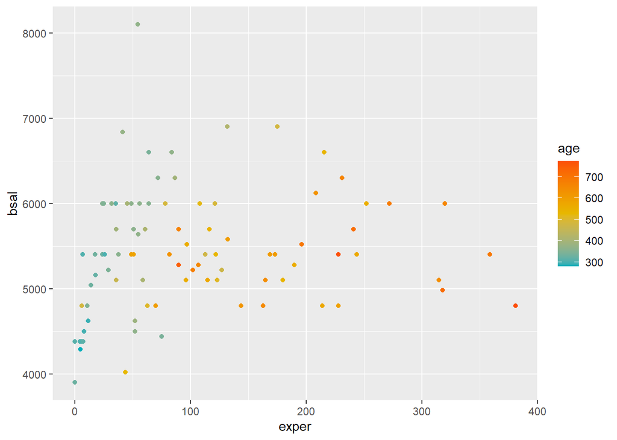

```r
ggplot(banksalary, aes(x = exper, y = bsal)) +
geom_point(aes(color = age)) +
scale_color_gradientn(colors = c("#00AFBB", "#E7B800", "#FC4E07"))
```

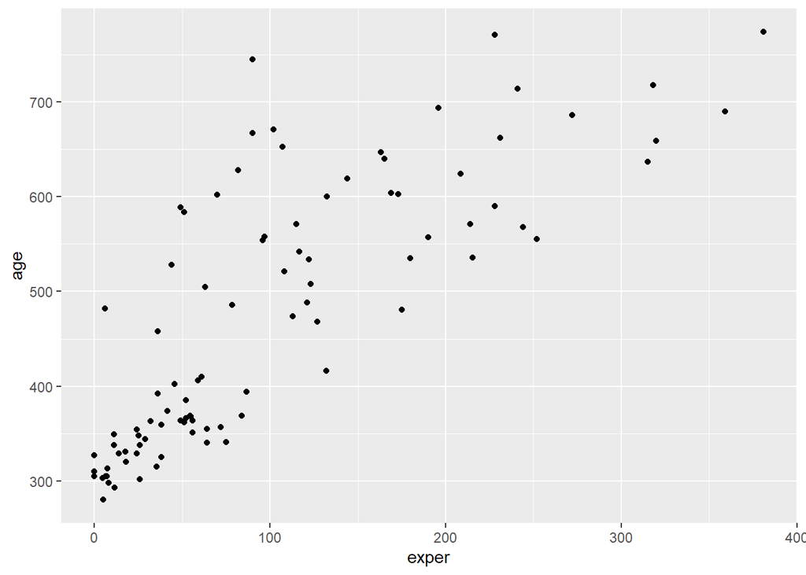

```r
ggplot(banksalary, aes(x = exper, y = age)) + geom_point()
```

- When age increases, experience increases.

```
k. A potential final model (Model 3) would contain terms for seniority, education, and experience in addition to sex.  Does this model meet all regression assumptions?  State a 95\% confidence interval for sex and interpret this interval carefully in the context of the problem.
```

```r
model_bank3 <- lm(bsal ~ senior + educ + exper + sex, data = banksalary)
summary(model_bank3)
```

```
##
## Call:
## lm(formula = bsal ~ senior + educ + exper + sex, data = banksalary)
##
## Residuals:
##     Min      1Q  Median      3Q     Max
## -1238.9  -353.1   -16.6   280.0  1568.8
##
## Coefficients:
##              Estimate Std. Error t value Pr(>|t|)
## (Intercept) 5845.7085   526.3677  11.106  < 2e-16 ***
## senior       -23.4276     5.2001  -4.505 2.03e-05 ***
## educ          90.0197    24.6932   3.646 0.000451 ***
## exper          1.2679     0.5871   2.160 0.033527 *
## sexMALE      722.3031   117.8246   6.130 2.42e-08 ***
## ---
## Signif. codes:  0 '***' 0.001 '**' 0.01 '*' 0.05 '.' 0.1 ' ' 1
##
## Residual standard error: 507.4 on 88 degrees of freedom
## Multiple R-squared:  0.5109, Adjusted R-squared:  0.4887
## F-statistic: 22.98 on 4 and 88 DF,  p-value: 5.068e-13
```

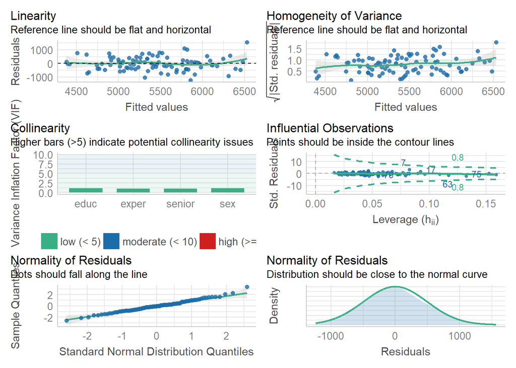

```r
check_model(model_bank3)
```

- Yes, this model appears to fulfill all the assumptions.

```r
confint(model_bank3)
```

```
##                    2.5 %      97.5 %
## (Intercept) 4799.6631702 6891.753734
## senior       -33.7616757  -13.093617
## educ          40.9471234  139.092269
## exper          0.1011406    2.434666
## sexMALE      488.1514633  956.454719
```

```
- We can be 95% confident that the starting salary of male is between 488.15 and 956.45 higher than female, after accounting for seniority, experience and education.

l. Based on Model 3, what conclusions can be drawn about gender discrimination at Harris Trust?  Do these conclusions have to be qualified at all, or are they pretty clear cut?
- There is a gender discrimination in starting salary at Harris Trust, after accounting for seniority, experience and education.

m. Often salary data is logged before analysis.  Would you recommend logging starting salary in this study?  Support your decision analytically.
```

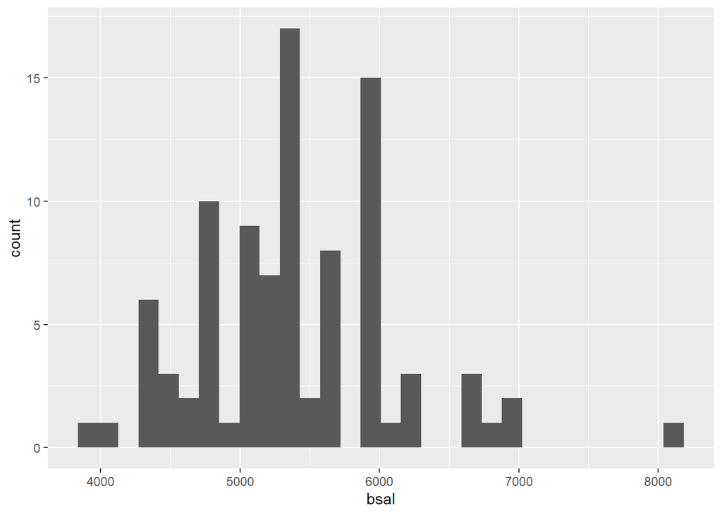

```r
ggplot(banksalary,aes(x=bsal))+
  geom_histogram()
```

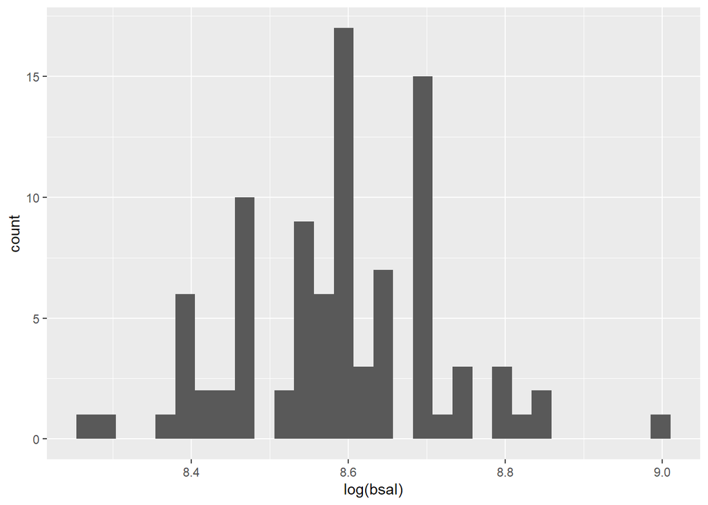

```r
ggplot(banksalary,aes(x=log(bsal)))+
  geom_histogram()
```

- The distribution of raw starting salary is positively skewed. We recommend logging the data in order to achieve normal distribution.

```
n. Regardless of your answer to the previous question, provide an interpretation for the coefficient for the male coefficient in a modified Model 3 after logging starting salary.
```

```r
model_bank4 <- lm(log(bsal) ~ senior + educ + exper + sex, data = banksalary)
summary(model_bank4)
```

```
##
## Call:
## lm(formula = log(bsal) ~ senior + educ + exper + sex, data = banksalary)
##
## Residuals:
##       Min        1Q    Median        3Q       Max
## -0.227738 -0.062870  0.000585  0.054120  0.209065
##
## Coefficients:
##               Estimate Std. Error t value Pr(>|t|)
## (Intercept)  8.6710332  0.0955077  90.789  < 2e-16 ***
## senior      -0.0043456  0.0009435  -4.606 1.38e-05 ***
## educ         0.0164092  0.0044805   3.662 0.000426 ***
## exper        0.0002611  0.0001065   2.451 0.016225 *
## sexMALE      0.1295564  0.0213789   6.060 3.30e-08 ***
## ---
## Signif. codes:  0 '***' 0.001 '**' 0.01 '*' 0.05 '.' 0.1 ' ' 1
##
## Residual standard error: 0.09207 on 88 degrees of freedom
## Multiple R-squared:  0.5144, Adjusted R-squared:  0.4923
## F-statistic:  23.3 on 4 and 88 DF,  p-value: 3.724e-13
```

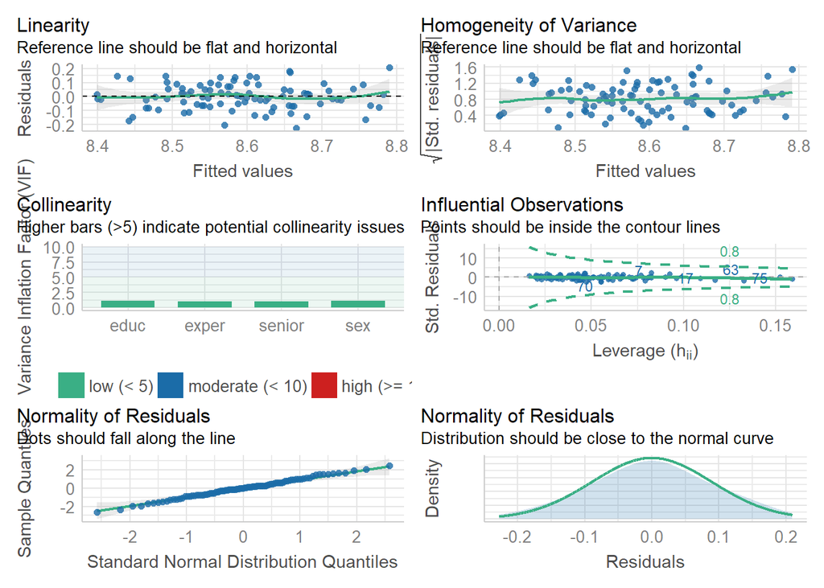

```r
check_model(model_bank4)
```

```
o. Build your own final model for this study and justify the selection of your final model.  You might consider interactions with gender, since those terms could show that discrimination is stronger among certain workers.  Based on your final model, do you find evidence of gender discrimination at Harris Trust?
```

```r
final_model1 <- lm(log(bsal) ~ senior + educ*sex + exper*sex, data = banksalary)
summary(final_model1)
```

```
##
## Call:
## lm(formula = log(bsal) ~ senior + educ * sex + exper * sex, data = banksalary)
##
## Residuals:
##       Min        1Q    Median        3Q       Max
## -0.224563 -0.063635 -0.002422  0.061495  0.198985
##
## Coefficients:
##                 Estimate Std. Error t value Pr(>|t|)
## (Intercept)    8.6806518  0.0994753  87.264  < 2e-16 ***
## senior        -0.0041651  0.0009525  -4.373 3.42e-05 ***
## educ           0.0135328  0.0051563   2.625   0.0103 *
## sexMALE        0.0220718  0.1496899   0.147   0.8831
## exper          0.0003621  0.0001405   2.577   0.0117 *
## educ:sexMALE   0.0096977  0.0107268   0.904   0.3685
## sexMALE:exper -0.0001935  0.0002223  -0.871   0.3864
## ---
## Signif. codes:  0 '***' 0.001 '**' 0.01 '*' 0.05 '.' 0.1 ' ' 1
##
## Residual standard error: 0.09206 on 86 degrees of freedom
## Multiple R-squared:  0.5255, Adjusted R-squared:  0.4924
## F-statistic: 15.87 on 6 and 86 DF,  p-value: 3.408e-12
```

```r
final_model2 <- lm(log(bsal) ~ senior + educ + exper*sex, data = banksalary)
summary(final_model2)
```

```
##
## Call:
## lm(formula = log(bsal) ~ senior + educ + exper * sex, data = banksalary)
##
## Residuals:
##       Min        1Q    Median        3Q       Max
## -0.240402 -0.069098  0.001357  0.061647  0.206244
##
## Coefficients:
##                 Estimate Std. Error t value Pr(>|t|)
## (Intercept)    8.6579174  0.0961433  90.052  < 2e-16 ***
## senior        -0.0042157  0.0009499  -4.438 2.65e-05 ***
## educ           0.0157819  0.0045117   3.498 0.000741 ***
## exper          0.0003615  0.0001403   2.576 0.011686 *
## sexMALE        0.1544333  0.0311457   4.958 3.48e-06 ***
## exper:sexMALE -0.0002377  0.0002166  -1.097 0.275575
## ---
## Signif. codes:  0 '***' 0.001 '**' 0.01 '*' 0.05 '.' 0.1 ' ' 1
##
## Residual standard error: 0.09196 on 87 degrees of freedom
## Multiple R-squared:  0.521,  Adjusted R-squared:  0.4935
## F-statistic: 18.93 on 5 and 87 DF,  p-value: 1.086e-12
```

```r
final_model3 <- lm(log(bsal) ~ senior + educ*sex + exper, data = banksalary)
summary(final_model3)
```

```
##
## Call:
## lm(formula = log(bsal) ~ senior + educ * sex + exper, data = banksalary)
##
## Residuals:
##       Min        1Q    Median        3Q       Max
## -0.211397 -0.060084 -0.003415  0.065412  0.194287
##
## Coefficients:
##                Estimate Std. Error t value Pr(>|t|)
## (Intercept)   8.6956259  0.0978411  88.875  < 2e-16 ***
## senior       -0.0042552  0.0009456  -4.500 2.09e-05 ***
## educ          0.0135430  0.0051491   2.630   0.0101 *
## sexMALE      -0.0252103  0.1392982  -0.181   0.8568
## exper         0.0002844  0.0001084   2.624   0.0102 *
## educ:sexMALE  0.0117494  0.0104502   1.124   0.2640
## ---
## Signif. codes:  0 '***' 0.001 '**' 0.01 '*' 0.05 '.' 0.1 ' ' 1
##
## Residual standard error: 0.09193 on 87 degrees of freedom
## Multiple R-squared:  0.5213, Adjusted R-squared:  0.4938
## F-statistic: 18.95 on 5 and 87 DF,  p-value: 1.055e-12
```

```r
final_model4 <- lm(log(bsal) ~ senior*sex + educ*sex + exper*sex, data = banksalary)
summary(final_model4)
```

```
##
## Call:
## lm(formula = log(bsal) ~ senior * sex + educ * sex + exper *
##     sex, data = banksalary)
##
## Residuals:
##       Min        1Q    Median        3Q       Max
## -0.223231 -0.062730 -0.003468  0.061834  0.198098
##
## Coefficients:
##                  Estimate Std. Error t value Pr(>|t|)
## (Intercept)     8.6877908  0.1124019  77.292  < 2e-16 ***
## senior         -0.0042547  0.0011538  -3.688 0.000398 ***
## sexMALE        -0.0024968  0.2318437  -0.011 0.991433
## educ            0.0135620  0.0051902   2.613 0.010612 *
## exper           0.0003603  0.0001419   2.539 0.012930 *
## senior:sexMALE  0.0002885  0.0020701   0.139 0.889505
## sexMALE:educ    0.0097349  0.0107918   0.902 0.369569
## sexMALE:exper  -0.0001928  0.0002236  -0.862 0.391163
## ---
## Signif. codes:  0 '***' 0.001 '**' 0.01 '*' 0.05 '.' 0.1 ' ' 1
##
## Residual standard error: 0.09259 on 85 degrees of freedom
## Multiple R-squared:  0.5256, Adjusted R-squared:  0.4865
## F-statistic: 13.45 on 7 and 85 DF,  p-value: 1.422e-11
```

```r
compare_performance(final_model1,final_model2,final_model3,final_model4)
```

```
## # Comparison of Model Performance Indices
##
## Name         | Model |      AIC |      BIC |    R2 | R2 (adj.) |  RMSE | Sigma
## ------------------------------------------------------------------------------
## final_model1 |    lm | -171.025 | -150.764 | 0.526 |     0.492 | 0.089 | 0.092
## final_model2 |    lm | -172.145 | -154.417 | 0.521 |     0.493 | 0.089 | 0.092
## final_model3 |    lm | -172.209 | -154.480 | 0.521 |     0.494 | 0.089 | 0.092
## final_model4 |    lm | -169.046 | -146.253 | 0.526 |     0.487 | 0.089 | 0.093
```

```r
anova(final_model1,final_model2)
```

```
## Analysis of Variance Table
##
## Model 1: log(bsal) ~ senior + educ * sex + exper * sex
## Model 2: log(bsal) ~ senior + educ + exper * sex
##   Res.Df     RSS Df  Sum of Sq      F Pr(>F)
## 1     86 0.72884
## 2     87 0.73577 -1 -0.0069268 0.8173 0.3685
```

```r
anova(final_model1,final_model3)
```

```
## Analysis of Variance Table
##
## Model 1: log(bsal) ~ senior + educ * sex + exper * sex
## Model 2: log(bsal) ~ senior + educ * sex + exper
##   Res.Df     RSS Df  Sum of Sq      F Pr(>F)
## 1     86 0.72884
## 2     87 0.73527 -1 -0.0064248 0.7581 0.3864
```

```r
anova(final_model1,final_model4)
```

```
## Analysis of Variance Table
##
## Model 1: log(bsal) ~ senior + educ * sex + exper * sex
## Model 2: log(bsal) ~ senior * sex + educ * sex + exper * sex
##   Res.Df     RSS Df  Sum of Sq      F Pr(>F)
## 1     86 0.72884
## 2     85 0.72868  1 0.00016646 0.0194 0.8895
```

[output not shown]

1. **Sitting and MTL thickness.** @Siddarth2018 researched relations between time spent sitting (sedentary behavior) and the thickness of a participant’s medial temporal lobe (MTL) in a 2018 paper entitled, “Sedentary behavior associated with reduced medial temporal lobe thickness in middle-aged and older adults”. MTL volume is negatively associated with Alzheimer’s disease and memory impairment. Their data on 35 adults can be found in `sitting.csv`. Key variables include:
   - `MTL` = Medial temporal lobe thickness in mm
   - `sitting` = Reported hours/day spent sitting
   - `MET` = Reported metabolic equivalent unit minutes per week
   - `age` = Age in years
   - `sex` = Sex (`M` = Male, `F` = Female)
   - `education` = Years of education completed
1. In their article’s introduction, Siddarth et al. differentiate their analysis on sedentary behavior from an analysis on active behavior by citing evidence supporting the claim that, “one can be highly active yet still be sedentary for most of the day.” Fit your own linear model with `MET` and `sitting` as your explanatory and response variables, respectively. Using $R^2$, how much of the subject to subject variability in hours/day spent sitting can be explained by MET minutes per week? Does this support the claim that sedentary behaviors may be independent from physical activity?
2. In the paper’s section, “Statistical analysis”, the authors report that, “Due to the skewed distribution of physical activity levels, we used log-transformed values in all analyses using continuous physical activity measures.” Generate both a histogram of `MET` values and log–transformed `MET` values. Do you agree with the paper’s decision to use a log-transformation here?
3. Fit a preliminary model with `MTL` as the response and `sitting` as the sole explanatory variable. Are LLSR conditions satisfied?
4. Expand on your previous model by including a centered version of `age` as a covariate. Interpret all three coefficients in this model.
5. One model fit in @Siddarth2018 includes `sitting`, log–transformed `MET`, and `age` as explanatory variables. They report an estimate $\hat{\beta}_{1} = -0.02$ with confidence interval $(-0.04,-0.002)$ for the coefficient corresponding to `sitting`, and $\hat{\beta}_{2} = 0.007$ with confidence interval $(-0.07, 0.08)$ for the coefficient corresponding to `MET`. Verify these intervals and estimates on your own.
6. Based on your confidence intervals from the previous part, do you support the paper’s claim that, “it is possible that sedentary behavior is a more significant predictor of brain structure, specifically MTL thickness [than physical activity]”? Why or why not?
7. A *New York Times* article was published discussing @Siddarth2018 with the title “Standing Up at Your Desk Could Make You Smarter” [@Friedman2018]. Do you agree with this headline choice? Why or why not?
2. **Housing prices and log transformations.** The dataset `kingCountyHouses.csv` contains data on over 20,000 houses sold in King County, Washington [@harlfoxem]. The dataset includes the following variables:
   - `price` = selling price of the house
   - `date` = date house was sold, measured in days since January 1, 2014
   - `bedrooms` = number of bedrooms
   - `bathrooms` = number of bathrooms
   - `sqft` = interior square footage
   - `floors` = number of floors
   - `waterfront` = 1 if the house has a view of the waterfront, 0 otherwise
   - `yr_built` = year the house was built
   - `yr_renovated` = 0 if the house was never renovated, the year the house was renovated if else

We wish to create a linear model to predict a house’s selling price.

1. Generate appropriate graphs and summary statistics detailing both `price` and `sqft` individually and then together. What do you notice?
2. Fit a simple linear regression model with `price` as the response variable and `sqft` as the explanatory variable (Model 1). Interpret the slope coefficient $\beta_1$. Are all conditions met for linear regression?
3. Create a new variable, `logprice`, the natural log of `price`. Fit Model 2, where `logprice` is now the response variable and `sqft` is still the explanatory variable. Write out the regression line equation.
4. How does `logprice` change when `sqft` increases by 1?
5. Recall that $\log(a) - \log(b) = \log\big(\frac{a}{b}\big)$, and use this to derive how `price` changes as `sqft` increases by 1.
6. Are LLSR assumptions satisfied in Model 2? Why or why not?
7. Create a new variable, `logsqft`, the natural log of `sqft`. Fit Model 3 where `price` and `logsqft` are the response and explanatory variables, respectively. Write out the regression line equation.
8. How does predicted `price` change as `logsqft` increases by 1 in Model 3?
9. How does predicted `price` change as `sqft` increases by 1%? As a hint, this is the same as multiplying `sqft` by 1.01.
10. Are LLSR assumptions satisfied in Model 3? Why or why not?
11. Fit Model 4, with `logsqft` and `logprice` as the response and explanatory variables, respectively. Write out the regression line equation.
12. In Model 4, what is the effect on `price` corresponding to a 1% increase in `sqft`?
13. Are LLSR assumptions satisfied in Model 4? Why or why not?
14. Find another explanatory variable which can be added to Model 4 to create a model with a higher adjusted $R^2$ value. Interpret the coefficient of this added variable.

# Housing prices and log transformations

```r
library(tidyverse)
library(broom)
library(patchwork)
library(performance)

library(sjPlot)
library(sjmisc)
library(sjlabelled)
```

## Dataset

```r
housing <- read_csv("data/kingCountyHouses.csv")
head(housing, 10)
```

```
## # A tibble: 10 x 9
##     price  date bedrooms bathrooms  sqft floors waterfront yr_built yr_renovated
##     <dbl> <dbl>    <dbl>     <dbl> <dbl>  <dbl>      <dbl>    <dbl>        <dbl>
##  1 2.22e5   285        3      1     1180      1          0     1955            0
##  2 5.38e5   342        3      2.25  2570      2          0     1951         1991
##  3 1.8 e5   420        2      1      770      1          0     1933            0
##  4 6.04e5   342        4      3     1960      1          0     1965            0
##  5 5.1 e5   413        3      2     1680      1          0     1987            0
##  6 1.23e6   131        4      4.5   5420      1          0     2001            0
##  7 2.58e5   177        3      2.25  1715      2          0     1995            0
##  8 2.92e5   379        3      1.5   1060      1          0     1963            0
##  9 2.30e5   469        3      1     1780      1          0     1960            0
## 10 3.23e5   435        3      2.5   1890      2          0     2003            0
```

## GLM: A linear model to predict a house’s selling price

```r
df1 <- housing %>%
  select("price", "sqft")
summary(df1)
```

```
##      price              sqft
##  Min.   :  75000   Min.   :  290
##  1st Qu.: 321950   1st Qu.: 1427
##  Median : 450000   Median : 1910
##  Mean   : 540088   Mean   : 2080
##  3rd Qu.: 645000   3rd Qu.: 2550
##  Max.   :7700000   Max.   :13540
```

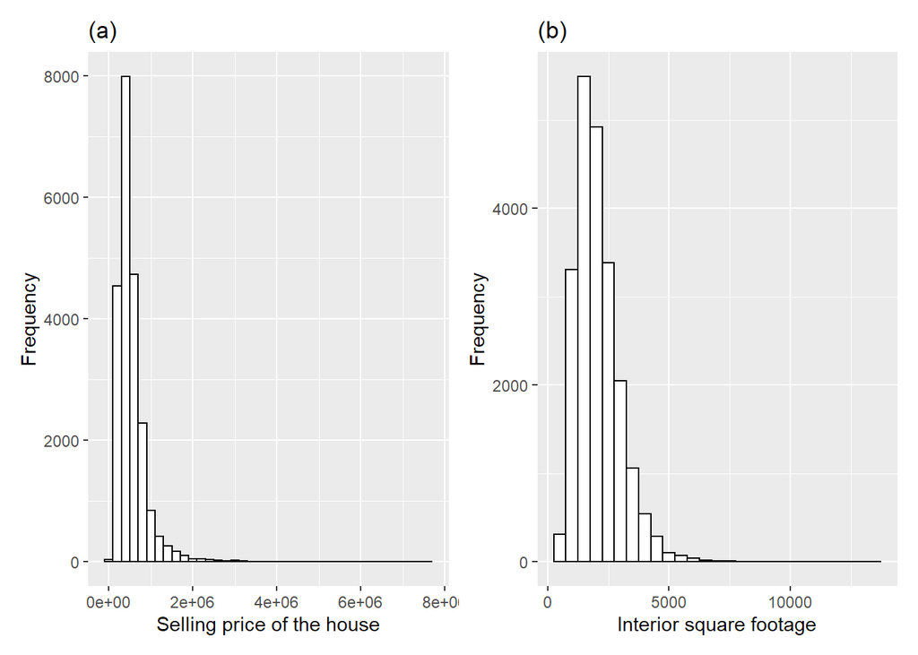

```r
## EDA graph

price_hist <- ggplot(data = housing, aes(x = price)) +
  geom_histogram(binwidth = 200000L, fill = "white",
                 color = "black") +
  xlab("Selling price of the house") +
  ylab("Frequency") +
  labs(title="(a)")

sqft_hist <- ggplot(data = housing, aes(x = sqft)) +
  geom_histogram(binwidth = 500, fill = "white",
                 color = "black") +
  xlab("Interior square footage") +
  ylab("Frequency") +
  labs(title="(b)")

price_hist|sqft_hist
```

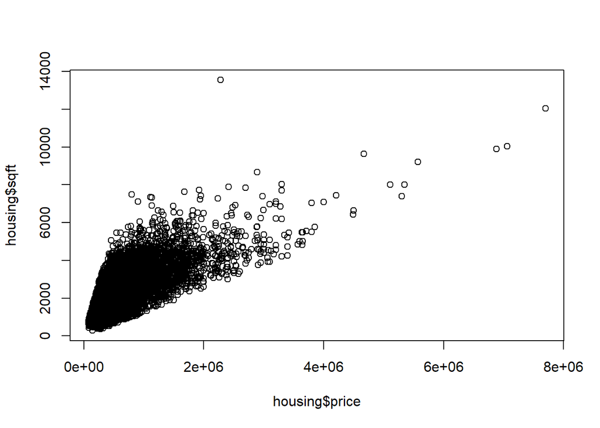

```r
plot(housing$price, housing$sqft)
```

Note: The selling price and square footage are both positively-skewed.

## Model 1: Simple linear regression model

```r
## Price as the function of sqft

m1 <- lm(price ~ sqft, data = housing)
tidy(summary(m1))
```

```
## # A tibble: 2 x 5
##   term        estimate std.error statistic  p.value
##   <chr>          <dbl>     <dbl>     <dbl>    <dbl>
## 1 (Intercept)  -43581.   4403.       -9.90 4.72e-23
## 2 sqft            281.      1.94    145.   0
```

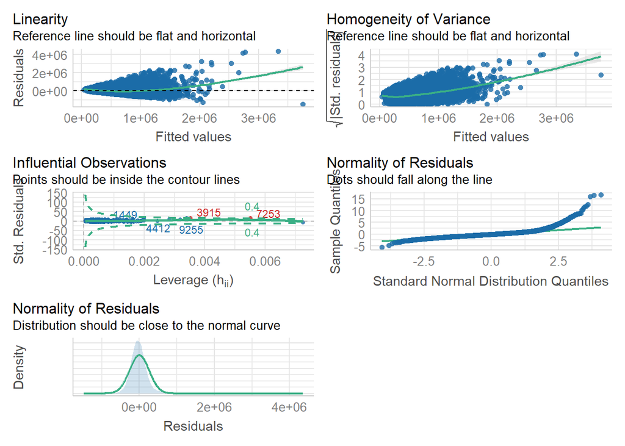

```r
check_model(m1)
```

There are violation in the assumptions. 1. I: There is no independence in the price. Houses with larger square feet are always sold at a higher price. 2. N: Data is not normal. It is positively-skewed. 3. E: Price are not distributed at each level of house square feet.

The slope coefficient _{1} is 280.624. The price increases by 280.624 dollars for each square feet increase.

## Model 2: Log transformation of Price

```r
housing <- housing %>%
  mutate(logprice = log(price))

m2 <- lm(logprice ~ sqft, data = housing)
tidy(summary(m2))
```

```
## # A tibble: 2 x 5
##   term         estimate  std.error statistic p.value
##   <chr>           <dbl>      <dbl>     <dbl>   <dbl>
## 1 (Intercept) 12.2      0.00637        1917.       0
## 2 sqft         0.000399 0.00000280      142.       0
```

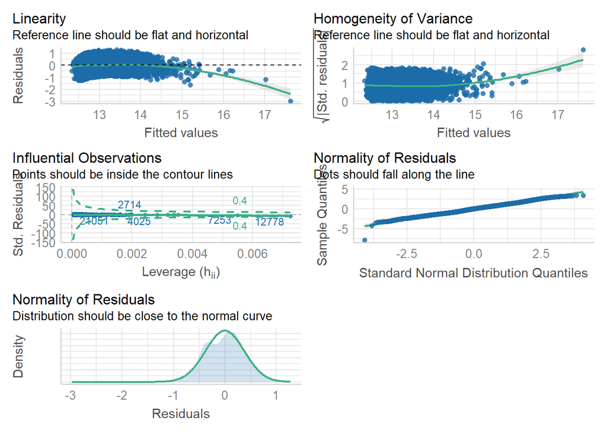

```r
check_model(m2)
```

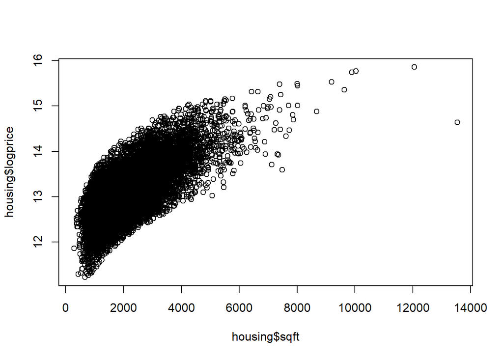

```r
plot(housing$sqft, housing$logprice)
```

```r
compare_performance(m1, m2)
```

```
## # Comparison of Model Performance Indices
##
## Name | Model |       AIC |       BIC |    R2 | R2 (adj.) |      RMSE |     Sigma
## --------------------------------------------------------------------------------
## m1   |    lm | 6.005e+05 | 6.006e+05 | 0.493 |     0.493 | 2.614e+05 | 2.615e+05
## m2   |    lm | 19346.318 | 19370.261 | 0.483 |     0.483 |     0.379 |     0.379
```

The price increases by 3.987e-04 with each 1 square feet increase.

## Model 3: Log transformation of sqft

```r
housing <- housing %>%
  mutate(logsqft = log(sqft))

m3 <- lm(price ~ logsqft, data = housing)
tidy(summary(m3))
```

```
## # A tibble: 2 x 5
##   term         estimate std.error statistic p.value
##   <chr>           <dbl>     <dbl>     <dbl>   <dbl>
## 1 (Intercept) -3451377.    35169.     -98.1       0
## 2 logsqft       528647.     4651.     114.        0
```

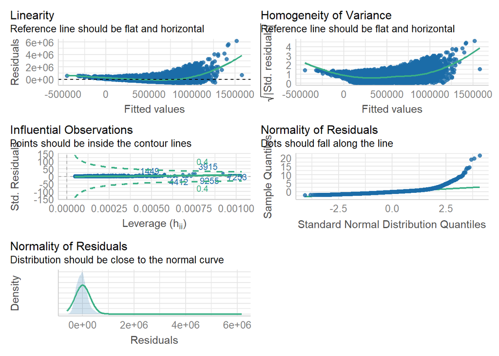

```r
check_model(m3)
```

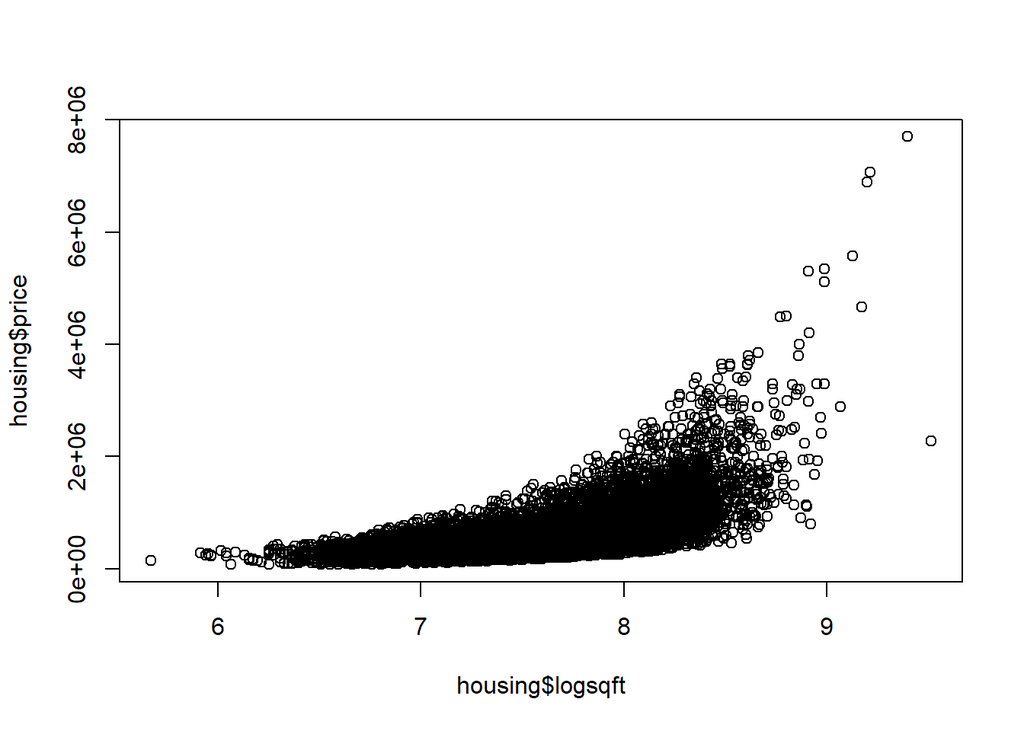

```r
plot(housing$logsqft, housing$price)
```

## Model 4: Log transformation of both variables

```r
m4 <- lm(logprice ~ logsqft, data = housing)
tidy(summary(m4))
```

```
## # A tibble: 2 x 5
##   term        estimate std.error statistic p.value
##   <chr>          <dbl>     <dbl>     <dbl>   <dbl>
## 1 (Intercept)    6.73    0.0471       143.       0
## 2 logsqft        0.837   0.00622      134.       0
```

[figure not shown]

```r
check_model(m1)
```

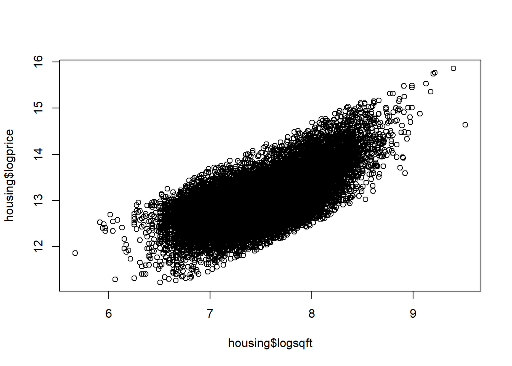

```r
plot(housing$logsqft, housing$logprice)
```

```r
compare_performance(m1, m2, m3, m4, rank = TRUE)
```

```
## # Comparison of Model Performance Indices
##
## Name | Model |       AIC |       BIC |    R2 | R2 (adj.) |      RMSE |     Sigma | Performance-Score
## ----------------------------------------------------------------------------------------------------
## m2   |    lm | 19346.318 | 19370.261 | 0.483 |     0.483 |     0.379 |     0.379 |            97.37%
## m4   |    lm | 20486.984 | 20510.928 | 0.456 |     0.455 |     0.389 |     0.389 |            89.45%
## m1   |    lm | 6.005e+05 | 6.006e+05 | 0.493 |     0.493 | 2.614e+05 | 2.615e+05 |            36.92%
## m3   |    lm | 6.051e+05 | 6.051e+05 | 0.374 |     0.374 | 2.904e+05 | 2.904e+05 |             0.00%
```

# Summary

```r
tab_model(m1, m2)
```

|  | price |  |  | logprice |  |  |
| --- | --- | --- | --- | --- | --- | --- |
| Predictors | Estimates | CI | p | Estimates | CI | p |
| (Intercept) | -43580.74 | -52210.34 – -34951.15 | **<0.001** | 12.22 | 12.21 – 12.23 | **<0.001** |
| sqft | 280.62 | 276.83 – 284.42 | **<0.001** | 0.00 | 0.00 – 0.00 | **<0.001** |
| Observations | 21613 |  |  | 21613 |  |  |
| R<sup>2</sup> / R<sup>2</sup> adjusted | 0.493 / 0.493 |  |  | 0.483 / 0.483 |  |  |

```r
tab_model(m3, m4)
```

|  | price |  |  | logprice |  |  |
| --- | --- | --- | --- | --- | --- | --- |
| Predictors | Estimates | CI | p | Estimates | CI | p |
| (Intercept) | -3451377.08 | -3520311.59 – -3382442.56 | **<0.001** | 6.73 | 6.64 – 6.82 | **<0.001** |
| logsqft | 528647.45 | 519531.87 – 537763.03 | **<0.001** | 0.84 | 0.82 – 0.85 | **<0.001** |
| Observations | 21613 |  |  | 21613 |  |  |
| R<sup>2</sup> / R<sup>2</sup> adjusted | 0.374 / 0.374 |  |  | 0.456 / 0.455 |  |  |

### Open-Ended Exercises

1. **The Bechdel Test.** In April, 2014, website FiveThirtyEight published the article, “The Dollar-And-Cents Case Against Hollywood’s Exclusion of Women” [@Hickey2014]. There, they analyze returns on investment for 1,615 films released between 1990 and 2013 based on the Bechdel test. The test, developed by cartoonist Alison Bechdel, measures gender bias in films by checking if a film meets three criteria:
   - there are at least two named women in the picture
   - they have a conversation with each other at some point
   - that conversation isn’t about a male character

While the test is not a perfect metric of gender bias, data from it does allow for statistical analysis. In the FiveThirtyEight article, they find that, “passing the Bechdel test had no effect on the film’s return on investment.” Their data can be found in `bechdel.csv`. Key variables include:

- `year` = the year the film premiered
- `pass` = 1 if the film passes the Bechdel test, 0 otherwise
- `budget` = budget in 2013 U.S. dollars
- `totalGross` = total gross earnings in 2013 U.S. dollars
- `domGross` = domestic gross earnings in 2013 U.S. dollars
- `intGross` = international gross earnings in 2013 U.S. dollars
- `totalROI` = total return on investment (total gross divided by budget)
- `domROI` = domestic return on investment
- `intROI` = international return on investment

With this in mind, carry out your own analysis. Does passing the Bechdel test have any effect on a film’s return on investment?

2. **Waitress tips.** A student collected data from a restaurant where she was a waitress [@Dahlquist2011]. The student was interested in learning under what conditions a waitress can expect the largest tips—for example: At dinner time or late at night? From younger or older patrons? From patrons receiving free meals? From patrons drinking alcohol? From patrons tipping with cash or credit? And should tip amount be measured as total dollar amount or as a percentage? Data can be found in `TipData.csv`. Here is a quick description of the variables collected:
   - `Day` = day of the week
   - `Meal` = time of day (Lunch, Dinner, Late Night)
   - `Payment` = how bill was paid (Credit, Cash, Credit with Cash tip)
   - `Party` = number of people in the party
   - `Age` = age category of person paying the bill (Yadult, Middle, SenCit)
   - `GiftCard` = was gift card used?
   - `Comps` = was part of the meal complimentary?
   - `Alcohol` = was alcohol purchased?
   - `Bday` = was a free birthday meal or treat given?
   - `Bill` = total size of the bill
   - `W.tip` = total amount paid (bill plus tip)
   - `Tip` = amount of the tip
   - `Tip.Percentage` = proportion of the bill represented by the tip